# Data 609: Homework 14

Integer/Discrete Programming via Branch and Bound

Aaron Grzasko

11/24/2017

## Assignment Overview

A company is assembling a team to carry out a series of operations. There are four members of the team: A, B, C and D, and four operations to be carried out. Each team member can carry out exactly one operation. All four operations must be carried out successfully for the overall project to succeed, however the probability of a particular team member succeeding in a particular operation varies, as shown in the table below. For example, if the team members were assigned to operations in the order ABCD, then the overall probability of successful completion of the project is (0.9)(0.6)(0.85)(0.7) = 0.3213. If there is any possible way that the team can be arranged such that the overall probability of success exceeds 45%, then the manager will approve the project. Will the manager approve the project? If yes, what is the arrangement of the team that gives the highest probability of success?

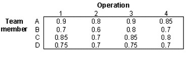

## Problem Formulation:

I will use a similar problem formulation as described in the background reading:

- *Meaning of a node in the branch and bound tree:* a partial or complete assignment of team members to operations.
- *Node selection policy:* global maximum of the bounding function
- *Variable selection policy:* choose operations in natural order, i.e. 1 through 4.
- *Bounding function:* choose the unassigned team member with the maximum probability, even if member was used in previous tasks. This function is less restrictive then the original problem constraint where individual team members can only be used once.
- *Terminating Rule:* when incumbent solution objective function is greater or equal to bounding function values associated with all bud nodes.

## Stage 1

At this point, we’ve made no decisions. That is, no team members have been assigned. We will simply choose the best member for each task. In this case, the maximum probability is generated by assigning member A to all tasks.

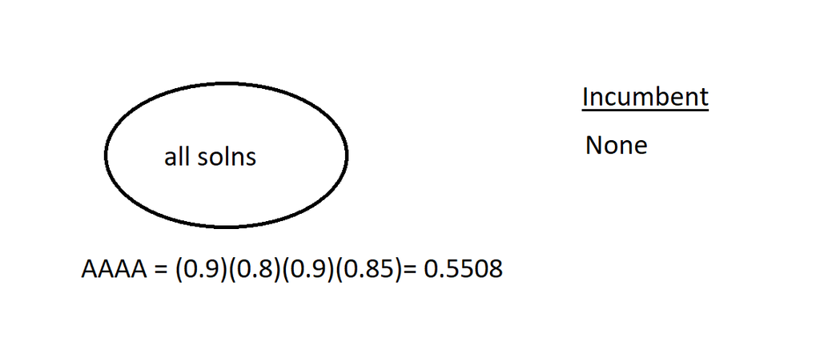

## Stage 2

Here we assign team members to operation 1; so the selected member cannot be repeated in subsequent tasks.  
Notes: For node A???, we arbitrarily selected the solution ACCC, but the solution ADCC would also have generated the same probability. None of the nodes produce a fathomable solution.

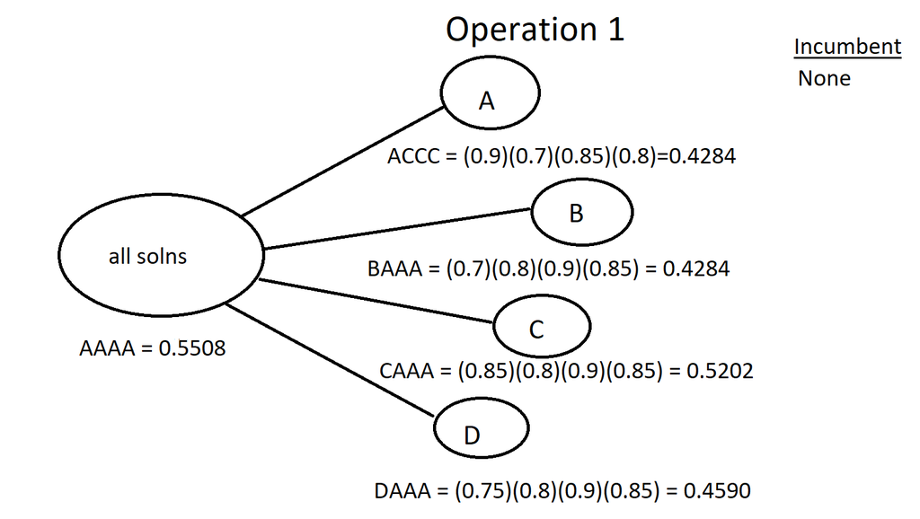

## Stage 3

In Stage two, we found that node C??? produced the maximum value of the bounding function; so we expand this node. We see that all node CADB produces a feasible solution, and we set permutation as our first incumbent solution.

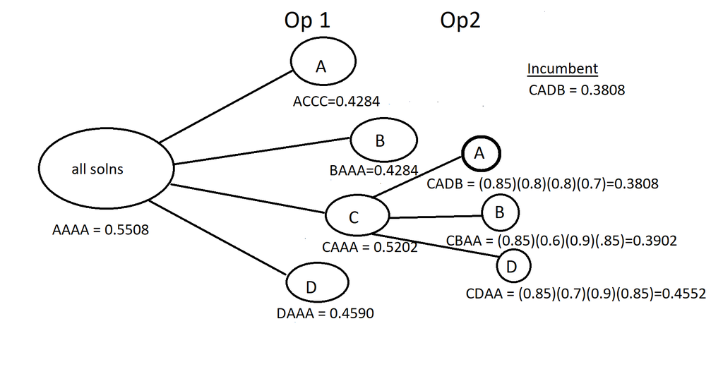

## Stage 4

From Stage 3, we note that node D??? has the highest bounding function value. Nodes CA??, CB??, and CD?? each produce probabilities less than 0.4590. We therefore expand node D???.

Node D??? is not fathomed; so we do not have a new incumbent solution. Also, the bounding function value of node DB?? is lower than the incumbent value; so we can prune this node.

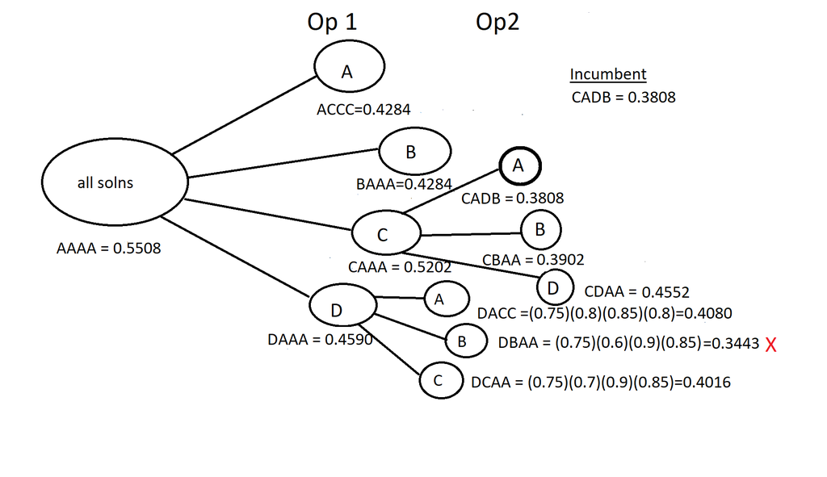

## Stage 5

At this point node CD?? has the highest bounding function value; therefore, we will branch here.  
Both CDAB and CDBA are feasible solutions, with CDBA’s value exceeding the current incumbent value; so this permutation will be our new incumbent solution. The bounding function value of node CDA? is lower than the incumbent value; so we can prune this node.

We can also prune live bud nodes with bounding values lower than the current incumbent. These include nodes CA??, CB??, and DC??.

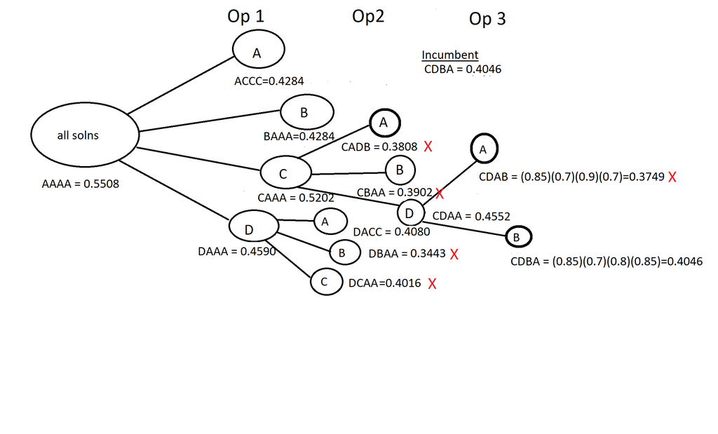

## Stage 6

Nodes A??? and B??? are tied with the highest bounding function values. We arbitrarily choose A??? to expand. We prune AB?? and AC?? because their values are lower than the incumbent solution.

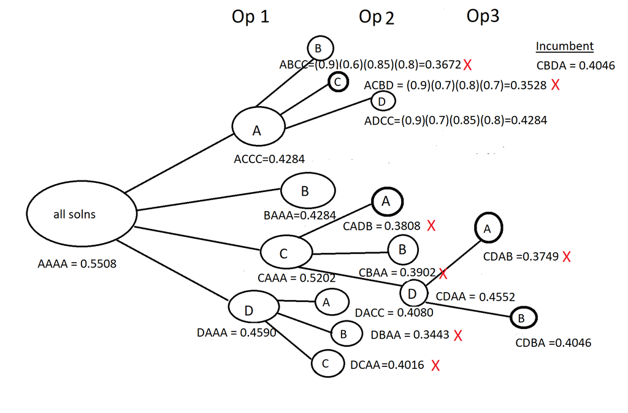

## Stage 7

Nodes AD?? and B??? are tied with the highest bounding function values. We arbitrarily choose AD?? for expansion. We produce two feasible solutions, ADBC and ADCB, but their values are both lower than the current incumbent solution. We therefore can prune ADB? and ADC?.

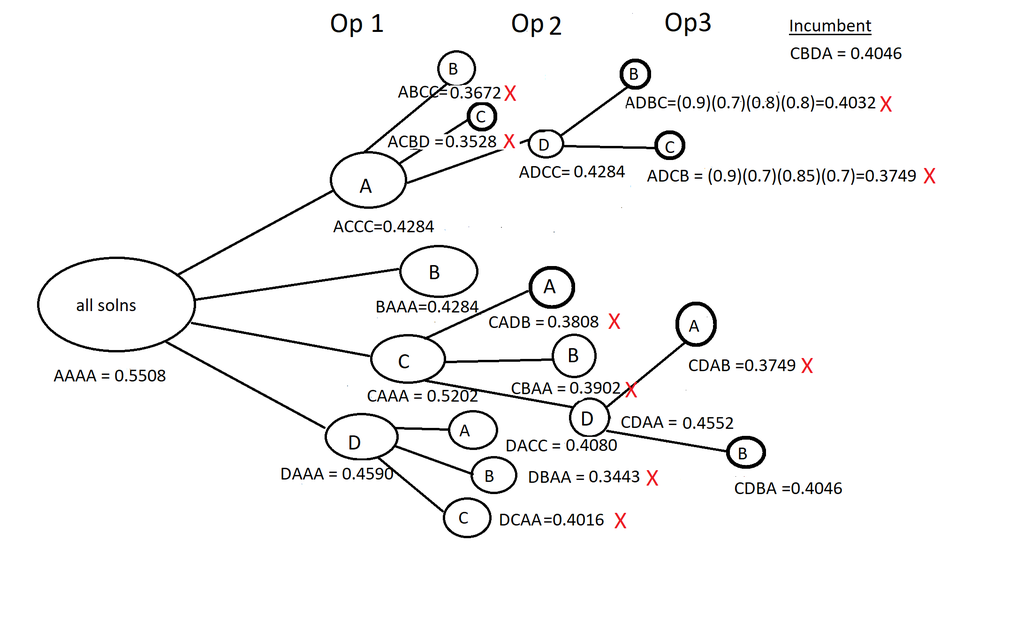

## Stage 8

At this point, node B??? has the highest bounding function value; so we will branch there. After expanding, we see BCAA and BDAA have bounding function values less that are less than the incumbent solution; so we can prune nodes BC?? and BD??.

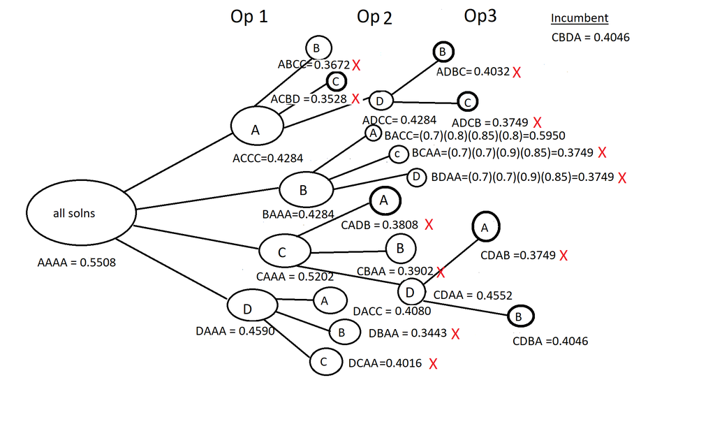

## Stage 9

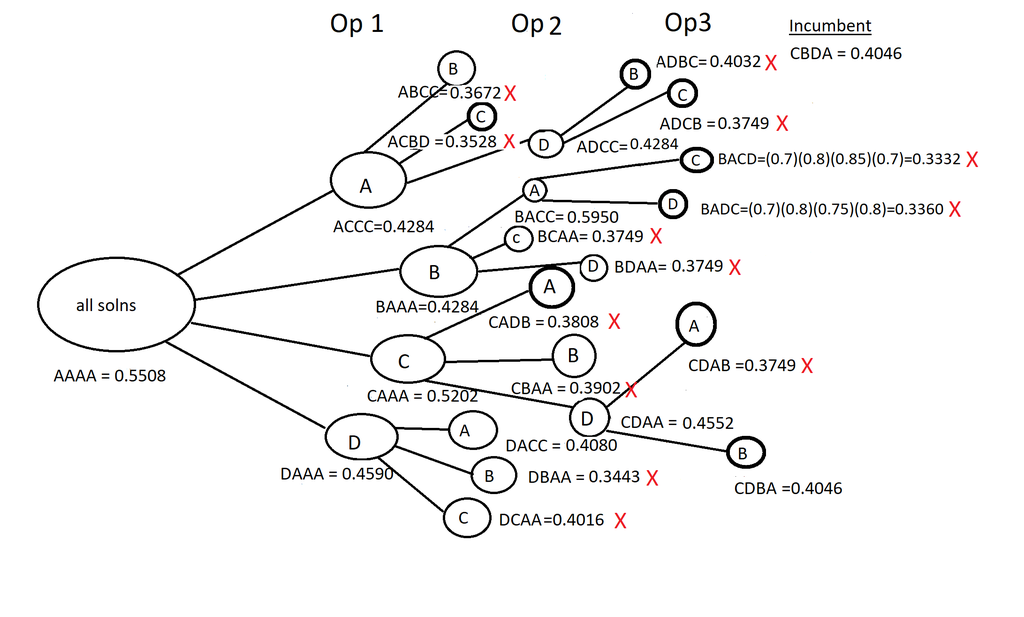

## Stage 10

We are left with one node, DA??, with a bounding function value greater than the incumbent solution. The diagram below shows the node expansion, which produces two feasible solutions: DABC and DACB. The probabilities associated with these two solutions are lower than the incumbent solution value; so we can prune at DAB? and DAC?

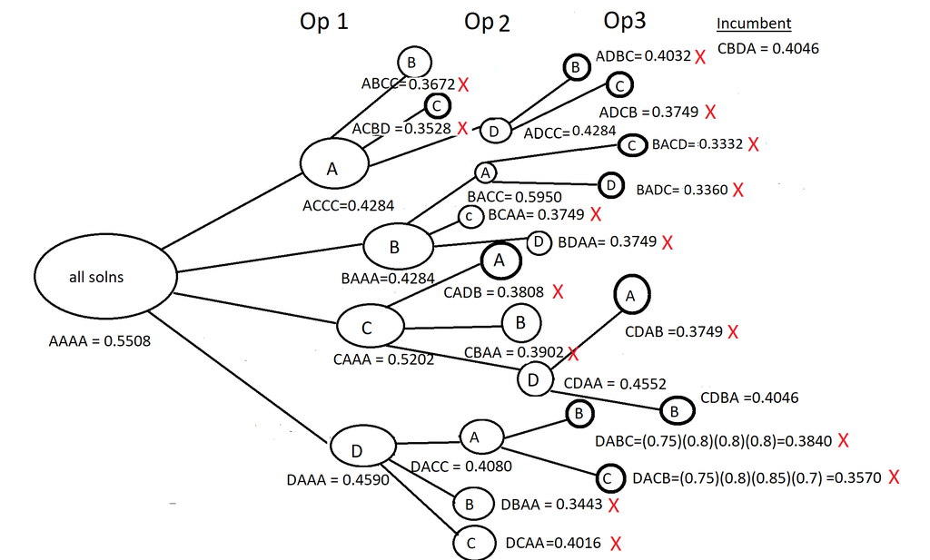

There are no additional nodes left to expand. We have found the maximum probability solution, CDBA.  
Because the maximum probability is less than minimum desired probability of 0.45, the manager will not approve of this project.